# Root finding methods

Thomas Achia

3/20/2023

## Analytical and numerical approaches to problems

See https://math.stackexchange.com/questions/935405/what-s-the-difference-between-analytical-and-numerical-approaches-to-problems#:~:text=Numerical%20methods%20use%20exact%20algorithms,the%20use%20of%20numerical%20methods.

**Analytical approach example:**

Find the root of $f(x)=x-5.$

**Analytical solution**: $f(x)=x-5=0,$ add $+5$ to both sides to get the answer $x=5$

**Numerical solution:**

let’s guess $x=1:~f(1)=1-5=-4.$ A negative number.

Let’s guess $x=6:~f(6)=6-5=1.$ A positive number.

This is called **bisection method.**

- Numerical solutions are extremely abundant.
- The main reason is that sometimes we either don’t have an analytical approach (try to solve $x^6-4x^5+\sin(x)-e^x+7-1^x=0)$ or that the analytical solution is too slow and instead of computing for 15 hours and getting an exact solution, we rather compute for 15 seconds and get a good approximation.

# NOTE

- Numerical methods use exact algorithms to present numerical solutions to mathematical problems.
- Analytic methods use exact theorems to present formulas that can be used to present numerical solutions to mathematical problems with or without the use of numerical methods.
- Analytical method gives exact solutions, more time consuming and sometimes impossible.
- Whereas numerical methods give approximate solution with allowable tolerance, less time and possible for most cases

**Analytical Method**

- When a problem is solved by means of analytical method its solution may be exact.
- it doesn’t follow any algorithm to solve a problem
- This method provides exact solution to a problem
- These problems are easy to solve and can be solved with pen and paper

**Numerical Method**

- When a problem is solved by mean of numerical method its solution may give an approximate number to a solution
- It is the subject concerned with the construction, analysis and use of algorithms to solve a problem
- It provides estimates that are very close to exact solution
- It can’t be solved with pen and paper but can be solved via computer tools like R, Python, FORTRAN or C++

# Bisection Method

- The bisection method is the easiest to numerically implement and almost always works.
- The main **disadvantage** is that **convergence is slow**.
- If the bisection method results in a computer program that runs too slow, then other faster methods may be chosen; otherwise it is a good choice of method.

We want to construct a sequence $x^{(0)},~x^{(1)},~x^{(2)}, \ldots$ that converges to the root $x = r$ that solves $f(x) = 0.$

- We choose $x^{(0)}$ and $x^{(1)}$ such that $x^{(0)} < r < x^{(1)}.$
- We say that $x^{(0)}$ and $x^{(1)}$ bracket the root.
- With $f(r) = 0,$ we want $f(x^{(0)})$ and $f(x^{(1)})$ to be of opposite sign, so that
  $$f(x^{(0)})\times f(x^{(1)}) < 0.$$

# Bisection Method-Cont.

We then assign $x^{(2)}$ to be the midpoint of $x^{(0)}$ and $x^{(1)},$ that is
$$x^{(2)} = \frac {x^{(0)} + x^{(1)}}{2},$$
or
$$x^{(2)} = x^{(0)} +\frac {x^{(1)} - x^{(0)}}{2}.$$
The sign of $f(x^{(2)})$ can then be determined.

The value of $x^{(3)}$ is then chosen as either the midpoint of $x^{(0)}$ and $x^{(2)}$ or as the midpoint of $x^{(2)}$ and $x^{(1)},$ depending on whether $x^{(0)}$ and $x^{(2)}$ bracket the root, or $x^{(2)}$ and $x^{(1)}$ bracket the root.

The root, therefore, stays bracketed at all times. The algorithm proceeds in this fashion and is typically stopped when the increment to the left side of the bracket (above, given by
$$\frac {x^{(1)} -x^{(0)}}{2}$$
is smaller than some required precision.

$$x^{(n+1)} = x^{(n-1)} +\frac {x^{(n)} - x^{(n-1)}}{2}.$$

# EXAMPLE-Bisection method

Suppose that we wish to implement the bisection method to maxima of the function
$$y=f(x)=\frac {\ln x}{1 + x}.$$
The plot of the function suggests that the maxima is potentially between $3$ and $4.$ See the following:

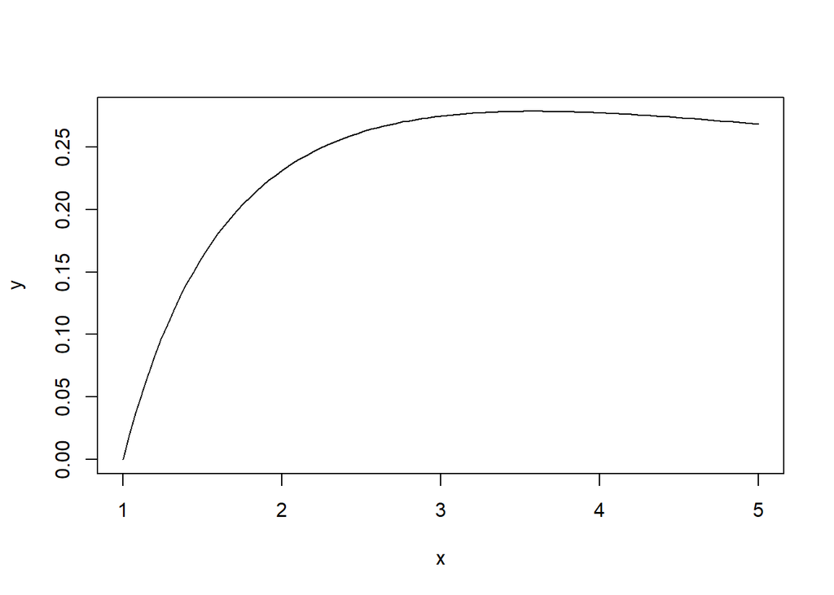

```r
curve(log(x)/(1+x), from=1, to=5, , xlab="x", ylab="y")
```

# Example-Cont.

Turning points for this curve will satisfy $f^\prime(x)=0.$ That is,
$$\frac {dy}{dx}=f^\prime(x)=\frac {1+\frac {1}{x}-\ln x}{(1 + x)^2}=0.$$
A plot of this first derivatives is:

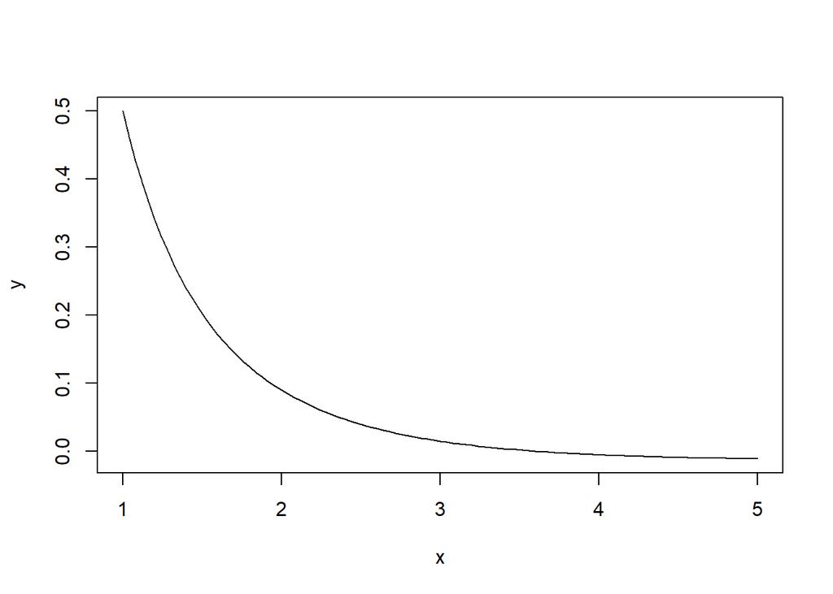

```r
curve((1+(1/x)-log(x))/(1+x)^2, from=1, to=5, , xlab="x", ylab="y")
```

# Example-R code

To find maxima of the equation $f(x)=\frac {\ln x}{1 + x}$ is thus equivalent to finding the root of $f^\prime(x)=\frac {1+\frac {1}{x}-\ln x}{(1 + x)^2}.$ A plot the function $f^\prime(x)$ has helped identify the bounds wherein the solution lies.

In this code **a** is the initial left endpoint, **b** is the initial right endpoint, **x** is the initial value, **itr** provides the number of iterations to run, **g** is the objective function, and **g.prime** is first derivative of objective function.

```r
## INITIAL VALUES
a = 1
b = 5
x = a+(b-a)/2
itr = 40

## FUNCTIONS
f = function(x){log(x)/(1+x)}
f.prime = function(x){(1+(1/x)-log(x))/((1+x)^2)}

## MAIN
for (i in 1:itr){
    if (f.prime(a)*f.prime(x) < 0) {b = x}
    else {a = x}
    x = a+(b-a)/2
}
```

# The Output

```r
x       # FINAL ESTIMATE
```

```
## [1] 3.591121
```

```r
f(x)        # OBJECTIVE FUNCTION AT ESTIMATE
```

```
## [1] 0.2784645
```

```r
f.prime(x)  # GRADIENT AT ESTIMATE
```

```
## [1] -1.121895e-14
```

# Newton’s Method

- This is a faster method, but requires analytical computation of the derivative of $f(x).$
- Also, the method **may not always converge** to the desired root.
- We can derive Newton’s Method graphically, or by a Taylor series.
- We again want to construct a sequence $x^{(0)}, x^{(1)}, x^{(2)},\ldots$ that converges to the root $x = r.$
- Consider the $x^{(n+1)}$ member of this sequence, and Taylor series expand $f(x^{(n+1)})$ about the point $x^{(n)}.$ We have
  $$f(x^{(n+1)}) = f(x^{(n)}) + (x^{(n+1)} - x^{(n)})f^\prime (x^{(n)}) +\ldots$$
  To determine $x^{(n+1)},$ we drop the higher-order terms in the Taylor series, and assume $f(x^{(n+1)}) = 0.$ That is,
  $$f(x^{(n+1)}) \approx f(x^{(n)}) + (x^{(n+1)} - x^{(n)})f^\prime (x^{(n)})\Rightarrow 0 \approx f(x^{(n)})+(x^{(n+1)} - x^{(n)})f^\prime (x^{(n)})$$

Solving for $x^{(n+1)},$ we have
$$x^{(n+1)} = x^{(n)} -\frac {f(x^{(n)})}{f^\prime (x^{(n)})}.$$
Starting Newton’s Method requires a guess for $x^{(0)},$ hopefully close to the root $x = r.$

# EXAMPLE-NEWTON’S METHOD